# Conceptos sobre Diseño experimental

Ago 2020  
Presione la **F** para ver en pantalla completa

## Glosario

- Experimento: Escenario en el cual un investigador impone de forma deliberada un tratamiento a una muestra de “sujetos” para evaluar su respuesta al tratamiento (LeBlanc, 2004).
- Diseño experimental: aspectos inherentes a la organización de un experimento (variables respuesta, tratamientos, unidades experimentales, asignación de unidades a tratamientos y replicación).
- El diseño experimental busca crear condiciones tales que sólo se puedan plantear dos posibles explicaciones para el porqué la respuesta difiere entre los “sujetos”: (1) el tratamiento causó la diferencia, o (2) la diferencia sólo se debe a la variación del muestreo aleatorio (LeBlanc, 2004).
- Respuesta: Variable aleatoria cuya variación interesa estudiar o sobre la cual recaen las hipótesis de interés.
- Factor: Variable (categórica) cuyos niveles definen los tratamientos o condiciones que se evaluaran para estudiar su efecto sobre la respuesta.
- Unidad experimental: Entidad (sujeto, caja de petri, parcela, etc.) que se asigna a un tratamiento.
- Replicación: Cuando hay más de una unidad experimental asignada a cada tratamiento. Permite estimar el error experimental.
- Error experimental: Variación de la respuesta que ocurre entre unidades exp. tratadas de la misma forma (o están en el mismo tratamiento).
- Bloque: Conjunto de unidades experimentales que tienen una o más características en común.

## Dos diseños clásicos: DCA y DBCA

### Diseño completamente aleatorio (DCA)

Las unidades experimentales se reparten al azar entre los tratamientos.

### Diseño en bloques completos al azar (DBCA)

Las unidades experimentales se agrupan en bloques y luego se reparten al azar entre los tratamientos, pero dentro de cada bloque.

## Diseño completamente aleatorio (DCA)

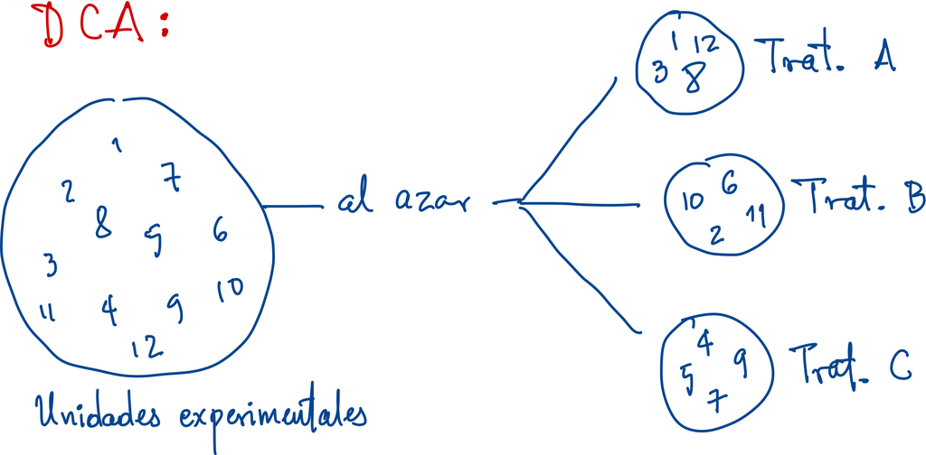

## Asignación en un DCA

```r
library(tidyverse)
library(randomizr)
dca <- tibble(
  ue = 1:12,
  trat = complete_ra(
    N = 12, num_arms = 3,
    conditions = c('T1', 'T2', 'T3'))
)

# UE's por trat:
xtabs(~ trat, data = dca)
```

```
#> trat
#> T1 T2 T3
#>  4  4  4
```

```r
dca  # imprimir la tabla
```

```
#> # A tibble: 12 x 2
#>       ue trat
#>    <int> <fct>
#>  1     1 T3
#>  2     2 T2
#>  3     3 T3
#>  4     4 T1
#>  5     5 T1
#>  6     6 T3
#>  7     7 T1
#>  8     8 T3
#>  9     9 T2
#> 10    10 T2
#> 11    11 T2
#> 12    12 T1
```

## Análisis de datos en un DCA

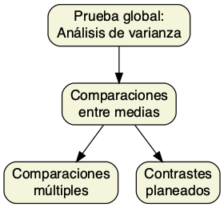

## Análisis de datos en un DCA

### **Análisis de varianza**

\[ H_0: \mu_1 = \mu_2 = \cdots = \mu_p \]

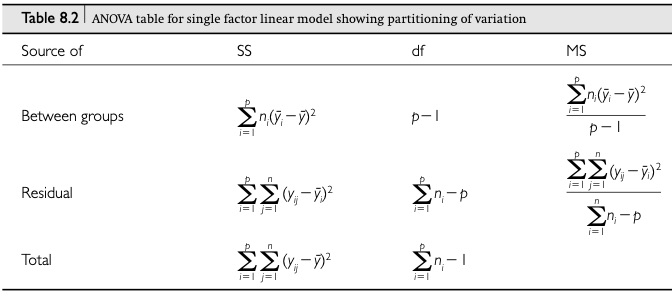

Tomado de Quinn & Keough (2002)

## Diseño en bloques completos al azar (DBCA)

Suponga que se quieren comparar \(p\) grupos o tratamientos y se cuenta con un total de \(pq\) unidades experimentales. Bajo un diseño en bloques completos al azar (DBCA):

- Se conforman grupos de unidades experimentales que tengan al menos una característica en común. Cada grupo formado se llama bloque y las características por las cuales se forman los bloques se les llama variables de bloqueo.
- Se forman \(q\) bloques. En cada bloque se incluyen \(p\) unidades experimentales.
- Los \(p\) tratamientos se asignan al azar a las unidades dentro de cada bloque.

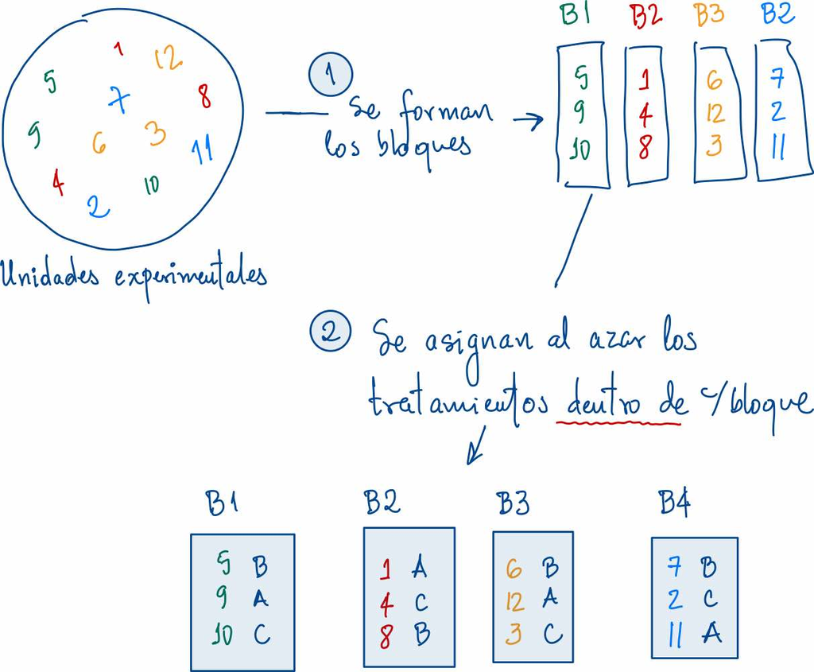

## Asignación en un DBCA

```r
library(tidyverse)
library(randomizr)
dbca <- tibble(
  ue = 1:12,
  bloque = c('B2', 'B4', 'B3', 'B2',
             'B1', 'B3', 'B4', 'B2',
             'B1', 'B1', 'B4', 'B3'),
  trat = block_ra(
    blocks = bloque, num_arms = 3,
    conditions = c('T1', 'T2', 'T3'))
)

# UE's por trat:
xtabs(~ bloque + trat, data = dbca)
```

```
#>       trat
#> bloque T1 T2 T3
#>     B1  1  1  1
#>     B2  1  1  1
#>     B3  1  1  1
#>     B4  1  1  1
```

```r
 # imprimir la tabla
arrange(dbca, bloque)
```

```
#> # A tibble: 12 x 3
#>       ue bloque trat
#>    <int> <chr>  <fct>
#>  1     5 B1     T1
#>  2     9 B1     T2
#>  3    10 B1     T3
#>  4     1 B2     T3
#>  5     4 B2     T1
#>  6     8 B2     T2
#>  7     3 B3     T3
#>  8     6 B3     T2
#>  9    12 B3     T1
#> 10     2 B4     T2
#> 11     7 B4     T1
#> 12    11 B4     T3
```

## Análisis de datos en DBCA

- En términos macro es el mismo que para un DCA.
- En el DBCA, el término del error o residual se divide en dos: una variación debida a los bloques y otra para el error como tal.

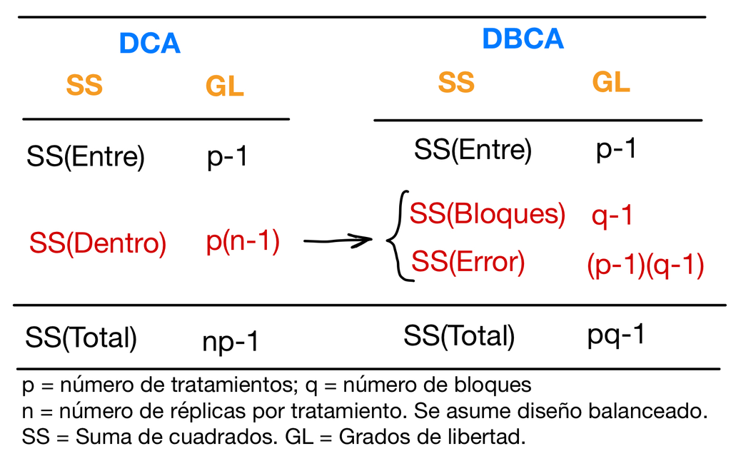

## Análisis de datos en DBCA

### **Análisis de varianza**

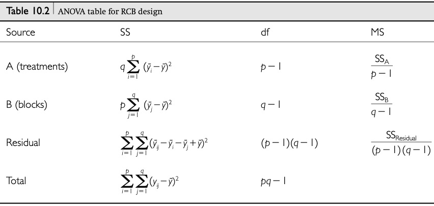

Tomado de Quinn & Keough (2002)

- El DBCA garantiza que las unidades experimentales que son asignadas a tratamientos diferentes, sean similares (o iguales) respecto a la variable de bloqueo.
- De esta forma, se remueve (controla) el posible ruido originado por esta variable de bloqueo y se espera que la varianza residual o del error disminuya respecto a no incluirla en el diseño.

## Análisis de datos en DBCA

### **Ejemplo: Aprendizaje de un dispositivo**

Se compararon \(p = 3\) métodos de enseñanza (A, B y C) de uso de un dispositivo prostético a pacientes que lo requieren. Dado que se piensa que la tasa de aprendizaje puede verse afectada por la edad de los pacientes, se utilizó la edad como un factor de bloqueo (Daniel & Cross, 2013).

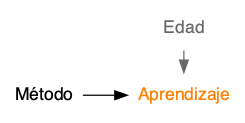

**Ejemplo: Aprendizaje de un dispositivo**

Tres pacientes de cada uno de \(q = 5\) grupos de edad fueron seleccionados para participar.

Luego, cada paciente, dentro de cada grupo de edad, fue asignado al azar a uno de los tres métodos.

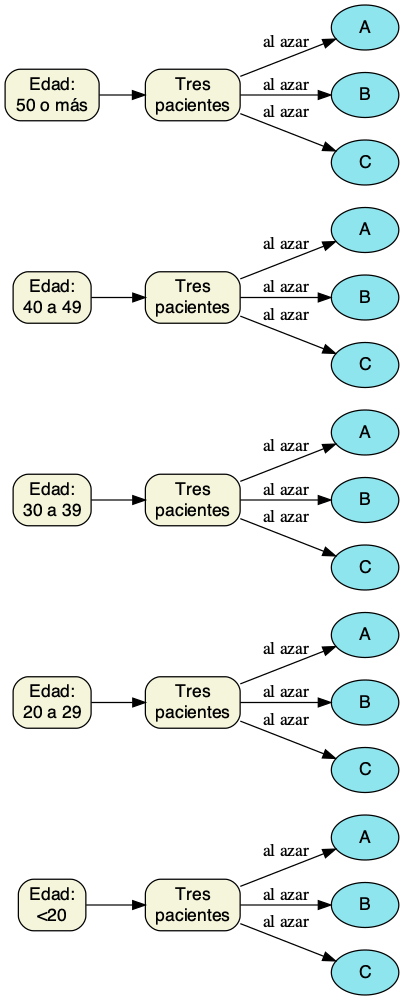

## Análisis de datos en DBCA

### **Ejemplo: Aprendizaje de un dispositivo**

```r
# Se entran los datos
disp <- tibble(
  edad   = gl(n = 5, k = 3,
              labels = c('<20', '20-29',
                         '30-39', '40-49',
                         '>50')),
  metodo = gl(n = 3, k = 1, length = 15,
              labels = c('A', 'B', 'C')),
  tiempo = c(7,9,10, 8,9,10, 9,9,12,
             10,9,12, 11,12,14)
)

# Cantidad de UE's por bloque y trat:
xtabs(~ metodo + edad, data = disp)
```

```
#>       edad
#> metodo <20 20-29 30-39 40-49 >50
#>      A   1     1     1     1   1
#>      B   1     1     1     1   1
#>      C   1     1     1     1   1
```

```r
disp  # se imprime la tabla
```

```
#> # A tibble: 15 x 3
#>    edad  metodo tiempo
#>    <fct> <fct>   <dbl>
#>  1 <20   A           7
#>  2 <20   B           9
#>  3 <20   C          10
#>  4 20-29 A           8
#>  5 20-29 B           9
#>  6 20-29 C          10
#>  7 30-39 A           9
#>  8 30-39 B           9
#>  9 30-39 C          12
#> 10 40-49 A          10
#> 11 40-49 B           9
#> 12 40-49 C          12
#> 13 >50   A          11
#> 14 >50   B          12
#> 15 >50   C          14
```

**Ejemplo: Aprendizaje de un dispositivo**

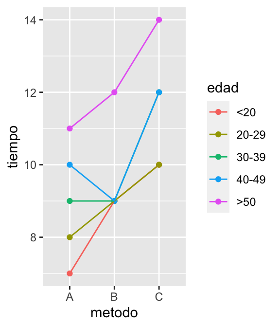

[figure not shown]

```r
# Grafico exploratorio
ggplot(disp, aes(x = metodo,
                 y = tiempo,
                 group = edad,
                 color = edad)) +
  geom_point() + geom_path()
```

**Ejemplo: Aprendizaje de un dispositivo**

```r
# Analisis de varianza
m <- lm(tiempo ~ metodo + edad, data = disp)
anova(m)
```

```
#> Analysis of Variance Table
#>
#> Response: tiempo
#>           Df  Sum Sq Mean Sq F value    Pr(>F)
#> metodo     2 18.5333  9.2667  21.385 0.0006165 ***
#> edad       4 24.9333  6.2333  14.385 0.0010017 **
#> Residuals  8  3.4667  0.4333
#> ---
#> Signif. codes:  0 '***' 0.001 '**' 0.01 '*' 0.05 '.' 0.1 ' ' 1
```

**Ejemplo: Aprendizaje de un dispositivo**

```r
# Analisis de varianza (asumiendo un DCA)
m0 <- lm(tiempo ~ metodo, data = disp)
anova(m0)
```

```
#> Analysis of Variance Table
#>
#> Response: tiempo
#>           Df Sum Sq Mean Sq F value  Pr(>F)
#> metodo     2 18.533  9.2667  3.9155 0.04909 *
#> Residuals 12 28.400  2.3667
#> ---
#> Signif. codes:  0 '***' 0.001 '**' 0.01 '*' 0.05 '.' 0.1 ' ' 1
```

**Ejemplo: Aprendizaje de un dispositivo**

```r
24.9333 + 3.4667         # = 28.4 = SS del Error en el DCA
```

```
#> [1] 28.4
```

```r
24.9333 / 28.4 * 100     # % del Error en el DCA debido a la edad  (=bloque)
```

```
#> [1] 87.79331
```

```r
 3.4667 / 28.4 * 100     # % del Error en el DCA debido a otras cosas
```

```
#> [1] 12.20669
```

**Ejemplo: Aprendizaje de un dispositivo**

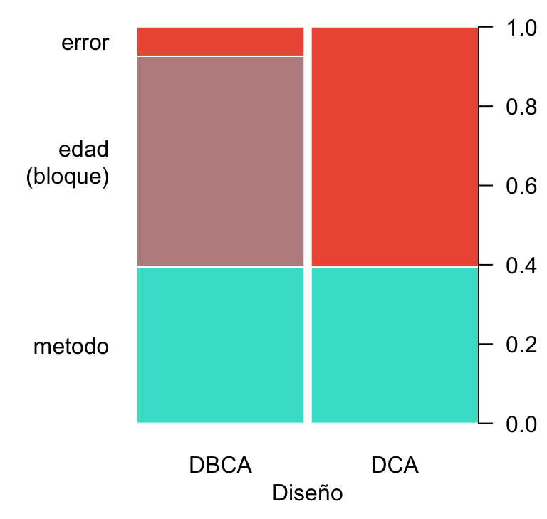

Distribución porcentual de la Suma de Cuadrados Total entre los dos diseños

## Grados de libertad en el DBCA

**Comparación de los grados de libertad del error entre un DCA y un DBCA**

En un DBCA, los grados de libertad del error se reducen con respecto a un DCA. Esto conlleva que el valor crítico de la \(F\) sea mayor y por ende, sea más díficil rechazar H\(_0\).

La ventaja del DBCA se encuentra en que se espera que la varianza del error disminuya, y por tanto el valor calculado del \(F\) sea más grande, como ocurrió con el ejemplo del tiempo de aprendizaje.

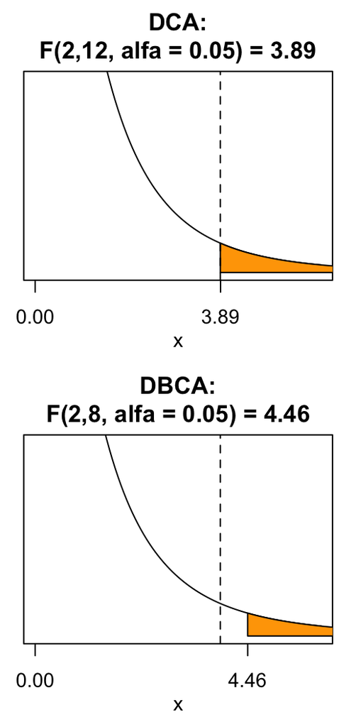

## Eficiencia relativa de la formación de bloques

Para medir que tan eficiente fue introducir la variable de bloqueo respecto a un DCA se puede calcular la **eficiencia relativa, RE**, dada por:

\[ RE = \left( \dfrac{v_2 + 1}{(v_2 + 3)s^2_2} \right) \div \left( \dfrac{v_1 + 1}{(v_1 + 3)s^2_1} \right) \]

donde el DCA es el 1 y el DBCA es el 2, \(v_1\) y \(v_2\) son los grados de libertad de los residuales de cada diseño, respectivamente. \(s^2_1\) y \(s^2_2\) son los cuadrados medios del error (MS\(_{res}\)) de cada diseño respectivamente. En general se coloca en el numerador los datos del diseño que se considera más eficiente.

## Eficiencia relativa de la formación de bloques

### **Interpretación**

- Si la RE \(> 1\) el diseño 2 (con el bloqueo) fue mejor que el diseño 1 (sin bloque, bajo un esquema completamente aleatorizado).
- Si la RE \(\leq 1\) el diseño 2 (con el bloqueo) no resultó más eficiente que el diseño 1.

## Eficiencia relativa de la formación de bloques

### **Cálculo en R**

Se construyó una función o comando personalizado para realizar el cálculo de la ER.

```r
# Se carga script R con funcion para calcular ER
# El archivo debe estar en el directorio de trabajo
source('er_bloques.R')
er_bloques(m1 = m0, m2 = m)   # se aplica la funcion
```

```
#>    modelo      CM_e  CV_e Efic_rel
#> 1  m1_DCA 2.3666667 15.28       NA
#> 2 m2_DBCA 0.4333333  6.54    5.156
```

## Comparando medias en el DBCA

```r
library(emmeans)
emmeans(m, ~ metodo, contr = 'pairwise')
```

```
#> $emmeans
#>  metodo emmean    SE df lower.CL upper.CL
#>  A         9.0 0.294  8     8.32     9.68
#>  B         9.6 0.294  8     8.92    10.28
#>  C        11.6 0.294  8    10.92    12.28
#>
#> Results are averaged over the levels of: edad
#> Confidence level used: 0.95
#>
#> $contrasts
#>  contrast estimate    SE df t.ratio p.value
#>  A - B        -0.6 0.416  8 -1.441  0.3667
#>  A - C        -2.6 0.416  8 -6.245  0.0006
#>  B - C        -2.0 0.416  8 -4.804  0.0034
#>
#> Results are averaged over the levels of: edad
#> P value adjustment: tukey method for comparing a family of 3 estimates
```

## Comparando medias en el DBCA

```r
# Grafico:
emmeans(m, ~ metodo) %>%
  plot(CIs = T, comparisons = T,
       horizontal = F)
```

Las flechas rojas en el gráfico indican las comparaciones múltiples. Si las flechas rojas se solapan, no hay diferencias a un nivel \(\alpha = 0.05\).

Los métodos A y B no difieren, y ambos difieren de C.

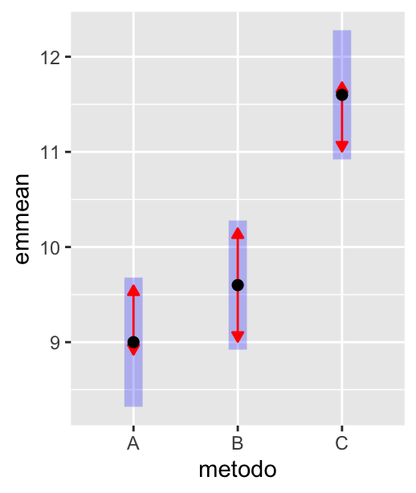

## Extensión: Dos o más factores

## Dos o más factores

- Los ejemplos anteriores han considero un sólo factor con \(p\) niveles. En este caso, cada nivel es un tratamiento.
- Cuando se busca evaluar más de un factor, cada uno con un cierto número de niveles, cada tratamiento equivale a una combinación particular de niveles de todos los factores.

## Referencias

Daniel, W. W., & Cross, C. L. (2013). *Biostatistics: A foundation for analysis in the health sciences* (10th ed.). Wiley.

LeBlanc, D. C. (2004). *Statistics: Concepts and applications for science*. Jones & Bartlett Publishers.

Quinn, G., & Keough, M. (2002). *Experimental design and data analysis for biologists*. New York: Cambridge University Press.